# A summary of the tweets generated at Botany 2017 (#Botany2017)

E.J. Rollinson

## About this document

This document was produced by [Emily J. Rollinson](http://rollinsonecology.com) (ejrollinson on Twitter).

The code generating this document was originally developed by [Francois Michonneau](https://github.com/fmichonneau) (fmic_ on Twitter) for the 2015 Evolution meeting and can be found [here](https://github.com/fmichonneau/evol2015-tweets).

It has since been [adapted](https://github.com/jlehtoma/iccb2015-tweets/blob/gh-pages/index.Rmd) for ICCB-ECCB 2015 by Joona Lehtomaki (jlehtoma on Twitter).

Thanks also to Emily Sessa (ebsessa on Twitter) for reproducing this code for the 2015 Botany meeting, bringing it to my attention.

I originally adapted this code for the 2015 Ecological Society of America meeting (#ESA100) in Baltimore, MD, and have since reproduced it for the 2016 ESA meeting (#ESA2016) in Fort Lauderdale, FL, and here for the 2017 Botany meeting (#Botany2017) in Fort Worth, Tx.

Tweets using the hashtag #Botany2017 were aggregated from Twitter using the R package [twitteR](https://cran.r-project.org/web/packages/twitteR/index.html) and the Twitter API. The aggregated tweets are [available on Figshare](https://figshare.com/articles/Tweets_using_Botany2017_hashtag/5160730).

This document was generated using RMarkdown, and the source is [available on GitHub](https://github.com/erollinson/erollinson.github.io).

This document (and associated code) is released under a CC0 licence.

## Basic summary

Of the 1714 tweets tagged #Botany2017 as of 6:30 PM EST 6/29/2017:

| Description | n |
| --- | --- |
| Total of original tweets (no retweets): | 697 |
| Number of users who tweeted: | 388 |

## The 5 most favorited tweets

> Standing room only for the Kaplan Lecture presented by Dan Chitwood! @PlantMorpho #Botany2017 https://t.co/eT4JtbzGfv

> — ajmiller4233 | [2017-06-27](https://twitter.com/ajmiller4233/status/879799588084998144) | 15 retweets, 64 favorites.

> Can now travel in style thanks to my #botanist luggage tag. Thanks to Blue Bee Hive Studios and #Botany2017 https://t.co/xgJVel8pFQ

> — Justine_Weber | [2017-06-26](https://twitter.com/Justine_Weber/status/879177709062172672) | 9 retweets, 59 favorites.

> No big deal, just partying two NAS members and @gypsumbotany. #botany2017 https://t.co/yMTCJqwCBT

> — Lagomarsino_L | [2017-06-29](https://twitter.com/Lagomarsino_L/status/880253352344473600) | 8 retweets, 48 favorites.

> #Bucknell botanists are checked in at Harrisburg airport & on our way to #Botany2017! https://t.co/5wAtIsd85z

> — MartineBotany | [2017-06-24](https://twitter.com/MartineBotany/status/878603030479982592) | 4 retweets, 45 favorites.

> . @Lagomarsino_L standing room only for Laura’s talk on speciation on Centropogon #Botany2017 https://t.co/TtD9Ykpl12

> — juliadupin | [2017-06-28](https://twitter.com/juliadupin/status/880184722940456960) | 7 retweets, 41 favorites.

## The 5 most retweeted tweets

> Recruiting #botany grad students to join Budke Lab @UTK_EEB fall 2018. Message me to chat at #Botany2017 https://t.co/bBldvwRvdY

> — MossPlants | [2017-06-25](https://twitter.com/MossPlants/status/879109948029972480) | 51 retweets, 26 favorites.

> Hey #botany2017 and #evol2017: I’m looking for grad students for Fall 2018 for lab @LSU_BioSci! #botany #phylogeny #Neotropics #pollination

> — Lagomarsino_L | [2017-06-26](https://twitter.com/Lagomarsino_L/status/879379740234326016) | 48 retweets, 29 favorites.

> Calling all #evol2017 and #botany2017 …. looking for great people to join us in our new digs at Yale https://t.co/xSFfxMVMgT

> — erikaedw | [2017-06-27](https://twitter.com/erikaedw/status/879715889997807616) | 44 retweets, 30 favorites.

> 4 a grad student to work on the evolution etc. of endemic Campanula in the Aegean Islands. Beautiful system, amazi https://t.co/T7ge9URNXL

> — ncellinese | [2017-06-27](https://twitter.com/ncellinese/status/879704672407351296) | 20 retweets, 35 favorites.

> Loren Rieseberg: teach our children to love nature before asking them to save it @mtsengphd #Botany2017

> — FriedmanJannice | [2017-06-28](https://twitter.com/FriedmanJannice/status/880203577754603520) | 18 retweets, 35 favorites.

## Top tweeters

All generated tweets (including retweets)

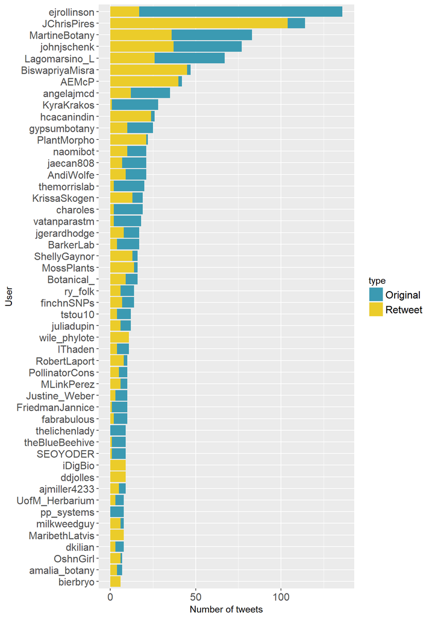

Only for original tweets (retweets excluded)

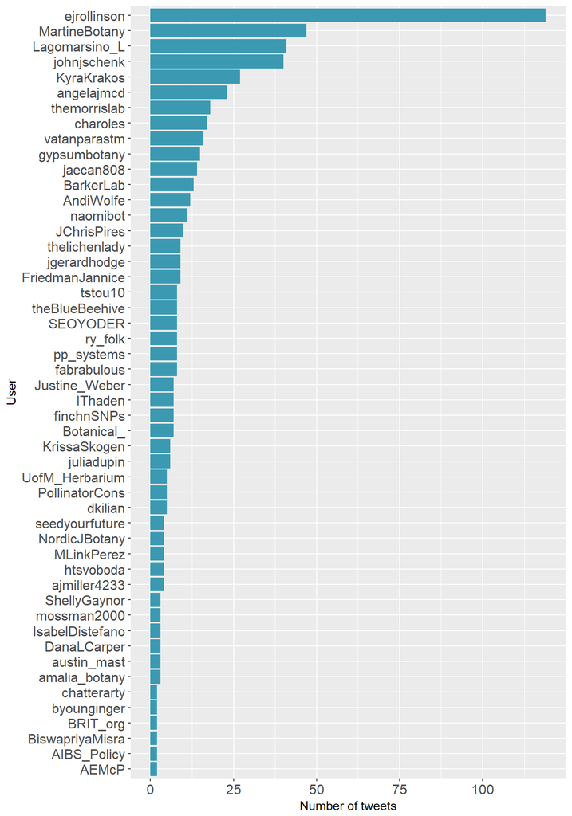

## Most favorited/retweeted users

The figures below only include users who tweeted 5+ times, and don’t include retweets.

### Number of favorites received by users

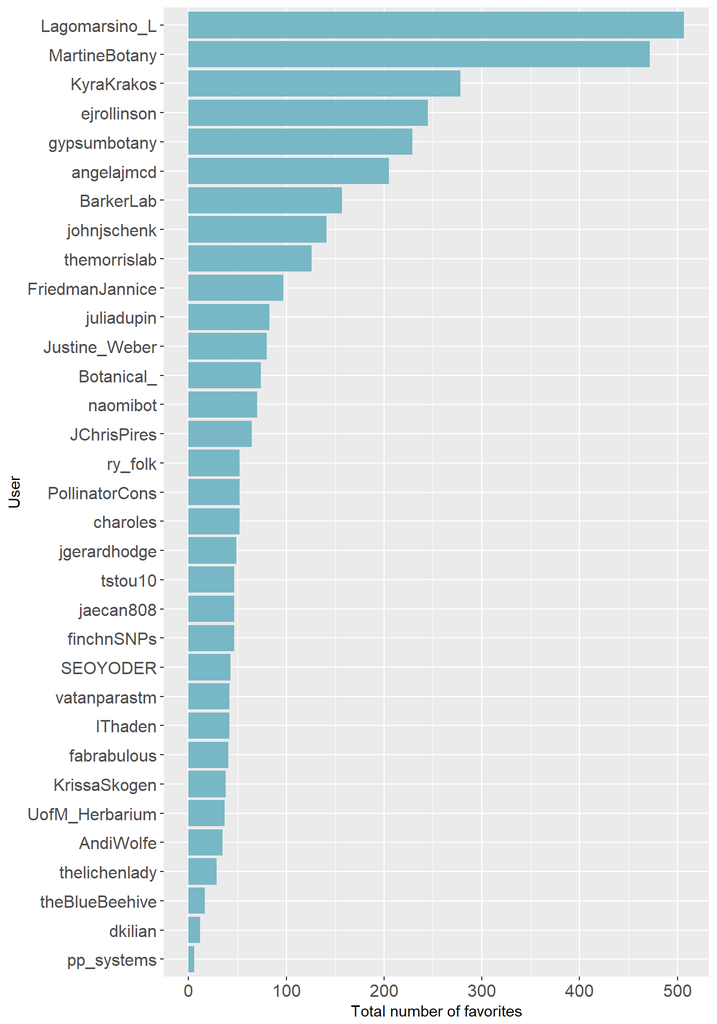

### Number of retweets received by users

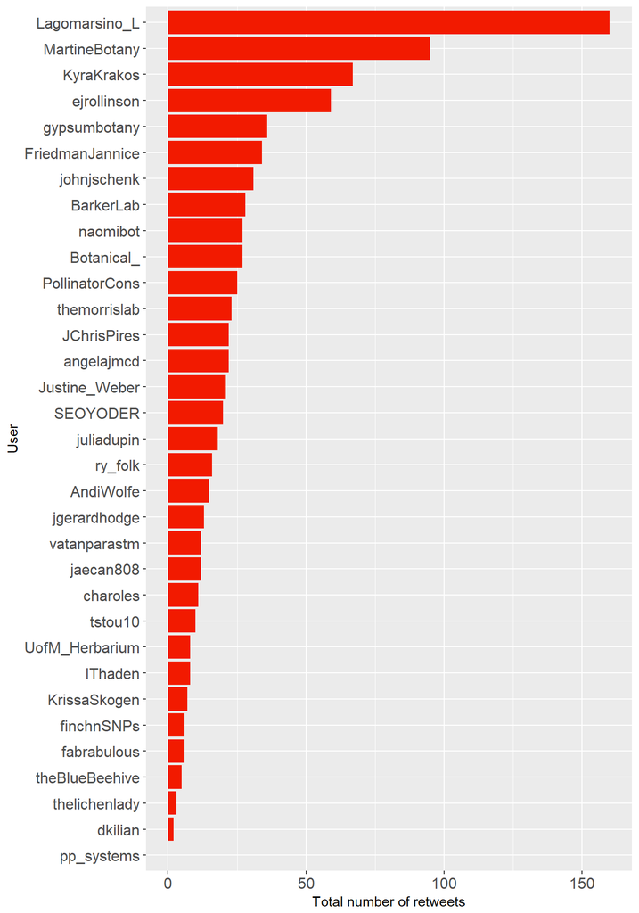

### Mean numbers of favorites received

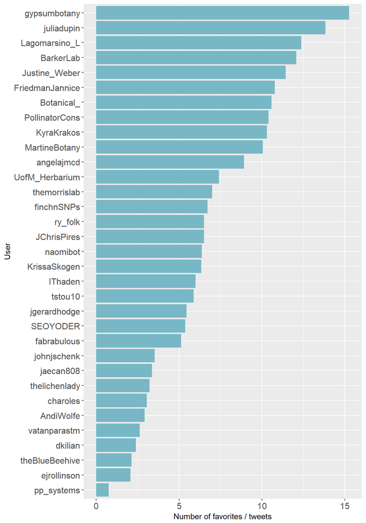

### Mean numbers of retweets received

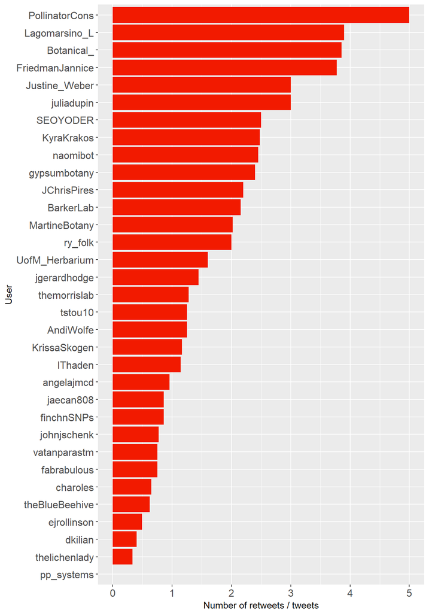

## Word cloud

The top 100 words among the original tweets.

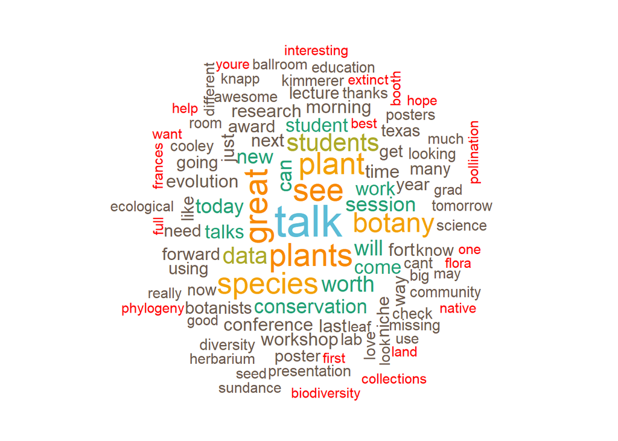

To the extent possible under law, [Emily J. Rollinson](https://github.com/erollinson/erollinson.github.io) has waived all copyright and related or neighboring rights to Summary of tweets at Botany 2017. This work is published from: United States.